# Lab 4: Data is Delicious

Author

Lily

**GitHub Repository**: https://github.com/lilysteinberg/GSB-544---Computing-and-ML/tree/main/Week%204

```python
# Libraries
import pandas as pd
import requests
from bs4 import BeautifulSoup
from sys import exit
import re
from plotnine import *
```

# 1. Data from unstructured websites

```python
# Set up webpage for Beautiful Soup scrape
URL = "https://tastesbetterfromscratch.com/meal-plan-199/"
HEADERS = {"User-Agent": "Mozilla/5.0 (Windows NT 10.0; Win64; x64)"}
response = requests.get(URL, headers=HEADERS)
soup = BeautifulSoup(response.text, "html.parser")
```

::: {#cell-Extracting Data from HTML for Monday .cell execution_count=3}

```python
# find info for Monday
day = soup.find_all("p", {"class": "has-text-align-left"})[1]

# find Monday's name
day.find("strong").text.replace('\xa0', ' ').replace('\xad', '').replace(':', '').strip()

# find Monday's name of recipe
day.find("a").text

# find Monday's link to recipe
day.find("a", href=True).get("href")

# find price of recipe - attempt 1
## only works for Monday because untagged dollar text moves position in html between days
day.find(string=True, recursive=False).strip()

# find price of recipe - attempt 2
## applicable to all days
re.search(r"\$\d+\.\d{2}", day.get_text(" ", strip=True)).group()
```

```
'$13.55'
```

:::

```python
# initialize an empty list
rows = []

# iterate over all rows
for day in soup.find_all("p", {"class": "has-text-align-left"})[0:]:

    # Find the the name of the day
    name_tag = day.find("strong")
    name = name_tag.text.replace('\xa0', ' ').replace('\xad', '').replace(':', '').strip()

    # Find the name of the recipe
    recipe_tag = day.find("a")
    recipe = recipe_tag.text

    # Find the link to the recipe
    link_tag = day.find("a", href=True)
    link = link_tag.get("href")

    # Find the price of the recipe
    price_tag = re.search(r"\$\d+\.\d{2}", day.get_text(" ", strip=True))
    price = price_tag.group()

    # Append this data.
    rows.append({
        "Day of the Week": name,
        "Name of Recipe": recipe,
        "Link to Recipe": link,
        "Price of Recipe": price
    })
```

::: {#cell-Sorting data into a pandas dataframe .cell execution_count=5}

```python
# sort data into pandas dataframe
pd.DataFrame(rows)
```

|  | Day of the Week | Name of Recipe | Link to Recipe | Price of Recipe |
| --- | --- | --- | --- | --- |
| 0 | Monday | Dirty Rice | https://tastesbetterfromscratch.com/dirty-rice/ | $14.66 |
| 1 | Tuesday | One Pan Pesto Chicken & Veggies | https://tastesbetterfromscratch.com/one-pan-pe... | $13.55 |
| 2 | Wednesday | Lentil Soup | https://tastesbetterfromscratch.com/lentil-soup/ | $14.60 |
| 3 | Thursday | Halloween Pizza | https://tastesbetterfromscratch.com/mini-hallo... | $6.68 |
| 4 | Friday | Cuban Sandwich | https://tastesbetterfromscratch.com/cuban-sand... | $15.53 |

:::

# 2. Data from an API

::: {#cell-Setting up the API .cell execution_count=6}

```python
# make variable for whatever "Monday" recipe could be
day_search_total = soup.find_all("p", {"class": "has-text-align-left"})[0]
day_search_specific = day_search_total.find("a").text

# set up API connection
url = "https://tasty.p.rapidapi.com/recipes/list"
querystring = {"from":"0","size":"100","q": day_search_specific}
headers = {
    "X-RapidAPI-Key": "bc5ff90f5dmsh5fc6a8ea4404132p14a19djsn36d29add3d45",
    "X-RapidAPI-Host": "tasty.p.rapidapi.com"
}

# scrape
response = requests.get(url, headers=headers, params=querystring)

# put results into dataframe (cleaned out unnecessary columns)
dirtyrice_recipes = pd.json_normalize(response.json(), "results")
dirtyrice_recipes = dirtyrice_recipes[['name', 'num_servings', 'total_time_minutes', 'video_url', 'user_ratings.score']]
dirtyrice_recipes
```

|  | name | num_servings | total_time_minutes | video_url | user_ratings.score |
| --- | --- | --- | --- | --- | --- |
| 0 | Lentil "Dirty Rice" | 4 | 45 | None | 0.714286 |

:::

# 3. Automate it

```python
def get_mealplan_data (num):
  """
  Provides recipes matching each day of the input mealplan.

  Parameters
  ----------
  num: int
    A number between 100-210, corresponding to a weekly mealplan from Tastes Better from Scratch.

  Return
  ------
  dataframe
    A dataframe containing 5 recipe options for each of the days in the specified mealplan.
  """

  ### Step 0: validate input
  if not num in range(100,211):
    exit("Please provide a number input between 100 and 210.")
  else:
    num = num

  ### Step 1: take input of 100-210 to find weekly meal plan
  URL = "https://tastesbetterfromscratch.com/meal-plan-"
  URL = URL + str(num) + "/"
  HEADERS = {"User-Agent": "Mozilla/5.0 (Windows NT 10.0; Win64; x64)"}
  response = requests.get(URL, headers=HEADERS)
  soup = BeautifulSoup(response.text, "html.parser")

  ### Step 2: scrape data from mealplan website

  # initialize an empty list
  rows = []

  # make the loop
  for day in soup.find_all("p", {"class": "has-text-align-left"})[0:]:

    # Find the the name of the day
    name_tag = day.find("strong")
    name = name_tag.text.replace('\xa0', ' ').replace('\xad', '').replace(':', '').strip()

    # Find the name of the recipe
    recipe_tag = day.find("a")
    recipe = recipe_tag.text

    # Find the link to the recipe
    link_tag = day.find("a", href=True)
    link = link_tag.get("href")

    # Find the price of the recipe
    price_tag = re.search(r"\$\d+\.\d{2}", day.get_text(" ", strip=True))
    price = price_tag.group()

    # Append this data.
    rows.append({
        "Day of the Week": name,
        "Name of Recipe": recipe,
        "Link to Recipe": link,
        "Price of Recipe": price
    })

  # sort data into pandas dataframe
  mealplan = pd.DataFrame(rows)

  ### Step 3: Query Tasty API for matching recipes

  # initialize an empty dataframe
  all_recipes = pd.DataFrame()

  # make the loop
  for i in mealplan.index:

    # set up API connection
    url_API = "https://tasty.p.rapidapi.com/recipes/list"
    querystring = {"from":"0","size":"100","q": mealplan.loc[i,"Name of Recipe"]}
    headers_API = {
        "X-RapidAPI-Key": "bc5ff90f5dmsh5fc6a8ea4404132p14a19djsn36d29add3d45",
        "X-RapidAPI-Host": "tasty.p.rapidapi.com"
    }

    # scrape
    response = requests.get(url_API, headers=headers_API, params=querystring)

    # put results into dataframe (cleaned out unnecessary columns)
    ## set up desired columns
    desired_cols = [
    'name', 'num_servings', 'total_time_minutes', 'video_url',
    'user_ratings.score', 'nutrition.calories', 'nutrition.carbohydrates',
    'nutrition.fat', 'nutrition.fiber', 'nutrition.protein', 'nutrition.sugar'
    ]

    # normalize and reindex
    day_recipes = pd.json_normalize(response.json(), "results")
    day_recipes = day_recipes.reindex(columns=desired_cols)

    # add column to help with eventual join with mealplan dataframe
    day_recipes['Name of Recipe'] = mealplan.loc[i,"Name of Recipe"]
    # join day_recipes to all_recipes df
    all_recipes = pd.concat([all_recipes, day_recipes])

  # Step 4: output a single dataset with all the info
  ## using left join in case Tasty does not have results for a mealplan day
  big_df = mealplan.merge(all_recipes, on='Name of Recipe', how="left")

  return big_df
```

Unit tests

::: {#unit-tests—-get_mealplan_data-(num .cell execution_count=8}

```python
#get_mealplan_data (133)
#get_mealplan_data (1)
#get_mealplan_data ("a")
#get_mealplan_data (True)
```

:::

Test with provided code

::: {#cell-Test with provided code .cell execution_count=9}

```python
df = get_mealplan_data(202)
df
```

|  | Day of the Week | Name of Recipe | Link to Recipe | Price of Recipe | name | num_servings | total_time_minutes | video_url | user_ratings.score | nutrition.calories | nutrition.carbohydrates | nutrition.fat | nutrition.fiber | nutrition.protein | nutrition.sugar |
| --- | --- | --- | --- | --- | --- | --- | --- | --- | --- | --- | --- | --- | --- | --- | --- |
| 0 | Monday | Chicken Divan | https://tastesbetterfromscratch.com/skinny-chi... | $10.82 | NaN | NaN | NaN | NaN | NaN | NaN | NaN | NaN | NaN | NaN | NaN |
| 1 | Tuesday | Beef Noodle Soup | https://tastesbetterfromscratch.com/beef-noodl... | $29.29 | Taiwanese Beef Noodle Soup | 6.0 | 210.0 | https://vid.tasty.co/output/92228/hls24_152528... | 0.982692 | 887.0 | 81.0 | 33.0 | 9.0 | 68.0 | 15.0 |
| 2 | Tuesday | Beef Noodle Soup | https://tastesbetterfromscratch.com/beef-noodl... | $29.29 | Classic Lasagna Soup | 4.0 | 35.0 | https://vid.tasty.co/output/210027/hls24_16268... | 0.954939 | 697.0 | 44.0 | 31.0 | 3.0 | 50.0 | 10.0 |
| 3 | Tuesday | Beef Noodle Soup | https://tastesbetterfromscratch.com/beef-noodl... | $29.29 | Traditional Vietnamese Beef Pho | 8.0 | 480.0 | https://vid.tasty.co/output/91445/hls24_152478... | 0.906114 | 539.0 | 59.0 | 20.0 | 3.0 | 27.0 | 3.0 |
| 4 | Tuesday | Beef Noodle Soup | https://tastesbetterfromscratch.com/beef-noodl... | $29.29 | 1-Day Noodles (Taiwanese Beef Noodle Soup) | 8.0 | 0.0 | https://vid.tasty.co/output/140619/hls24_15645... | 0.929825 | NaN | NaN | NaN | NaN | NaN | NaN |
| ... | ... | ... | ... | ... | ... | ... | ... | ... | ... | ... | ... | ... | ... | ... | ... |
| 77 | Friday | Chicken Gyros | https://tastesbetterfromscratch.com/chicken-gy... | $21.22 | 5 Fork-less Finger Foods | NaN | NaN | https://vid.tasty.co/output/106240/hls24_15349... | NaN | NaN | NaN | NaN | NaN | NaN | NaN |
| 78 | Friday | Chicken Gyros | https://tastesbetterfromscratch.com/chicken-gy... | $21.22 | Homemade American Street Foods | NaN | NaN | https://vid.tasty.co/output/197424/hls24_16165... | NaN | NaN | NaN | NaN | NaN | NaN | NaN |
| 79 | Friday | Chicken Gyros | https://tastesbetterfromscratch.com/chicken-gy... | $21.22 | Chicken Recipes For The Whole Month | NaN | NaN | https://vid.tasty.co/output/204707/hls24_16224... | NaN | NaN | NaN | NaN | NaN | NaN | NaN |
| 80 | Friday | Chicken Gyros | https://tastesbetterfromscratch.com/chicken-gy... | $21.22 | Tasty Dinners for Every Night of December | NaN | NaN | https://vid.tasty.co/output/264409/hls24_16698... | NaN | NaN | NaN | NaN | NaN | NaN | NaN |
| 81 | Friday | Chicken Gyros | https://tastesbetterfromscratch.com/chicken-gy... | $21.22 | 11 Street Food Recipes You Can Make At Home | NaN | NaN | https://vid.tasty.co/output/158404/hls24_15797... | NaN | NaN | NaN | NaN | NaN | NaN | NaN |

82 rows × 15 columns

:::

# 4. Add a column with fuzzy matching

I made this part into a function because later, to prepare the data for graphing, I had trouble keeping the original ‘Vegetarian?’ column through the .groupby() function and didn’t want to repeat the code when I re-added the column.

```python
def vegetarian (df):
  '''
  Adds a column that determines if the name of a recipe from the weekly mealplan is vegatrian or not.

  Parameter
  -------
  df: dataframe
    A dataframe containing a column called "Name of Recipe"

  Returns
  -------
  dataframe
    The same dataframe as input, now with a column for vegetrain determination based on the name of the recipe
  '''

  # validate df input
  if not 'Name of Recipe' in df.columns:
    exit("Please input a valid dataframe")

  # make list of meat words
  meat = ["beef", "chicken", "fish", "salmon", "tuna", "lamb", "pork", "veal", "seafood", "shrimp", "turkey", "meat", "meatball"]
  contains_meat = re.compile(r'\b(' + '|'.join(meat) + r')\b', flags=re.IGNORECASE)

  # search df for meat words using if/else and bools to sort
  ## added an 'N/A' result in case no Tasty recipe present
  df["Vegetarian?"] = df["Name of Recipe"].apply(lambda x: 'N/A' if pd.isna(x) else ('No' if contains_meat.search(x) else 'Yes'))
  return df
```

Unit test

::: {#unit-tests—-vegetarian-(df .cell execution_count=11}

```python
#data = {'col1': [1, 2, 3], 'col2': ['A', 'B', 'C']}
# abc = pd.DataFrame(data)
#vegetarian(abc)
```

:::

Using function for real

::: {#cell-Fuzzy matching for vegetrian options – using function .cell execution_count=12}

```python
# calling function
df = vegetarian(df)
df
```

|  | Day of the Week | Name of Recipe | Link to Recipe | Price of Recipe | name | num_servings | total_time_minutes | video_url | user_ratings.score | nutrition.calories | nutrition.carbohydrates | nutrition.fat | nutrition.fiber | nutrition.protein | nutrition.sugar | Vegetarian? |
| --- | --- | --- | --- | --- | --- | --- | --- | --- | --- | --- | --- | --- | --- | --- | --- | --- |
| 0 | Monday | Chicken Divan | https://tastesbetterfromscratch.com/skinny-chi... | $10.82 | NaN | NaN | NaN | NaN | NaN | NaN | NaN | NaN | NaN | NaN | NaN | No |
| 1 | Tuesday | Beef Noodle Soup | https://tastesbetterfromscratch.com/beef-noodl... | $29.29 | Taiwanese Beef Noodle Soup | 6.0 | 210.0 | https://vid.tasty.co/output/92228/hls24_152528... | 0.982692 | 887.0 | 81.0 | 33.0 | 9.0 | 68.0 | 15.0 | No |
| 2 | Tuesday | Beef Noodle Soup | https://tastesbetterfromscratch.com/beef-noodl... | $29.29 | Classic Lasagna Soup | 4.0 | 35.0 | https://vid.tasty.co/output/210027/hls24_16268... | 0.954939 | 697.0 | 44.0 | 31.0 | 3.0 | 50.0 | 10.0 | No |
| 3 | Tuesday | Beef Noodle Soup | https://tastesbetterfromscratch.com/beef-noodl... | $29.29 | Traditional Vietnamese Beef Pho | 8.0 | 480.0 | https://vid.tasty.co/output/91445/hls24_152478... | 0.906114 | 539.0 | 59.0 | 20.0 | 3.0 | 27.0 | 3.0 | No |
| 4 | Tuesday | Beef Noodle Soup | https://tastesbetterfromscratch.com/beef-noodl... | $29.29 | 1-Day Noodles (Taiwanese Beef Noodle Soup) | 8.0 | 0.0 | https://vid.tasty.co/output/140619/hls24_15645... | 0.929825 | NaN | NaN | NaN | NaN | NaN | NaN | No |
| ... | ... | ... | ... | ... | ... | ... | ... | ... | ... | ... | ... | ... | ... | ... | ... | ... |
| 77 | Friday | Chicken Gyros | https://tastesbetterfromscratch.com/chicken-gy... | $21.22 | 5 Fork-less Finger Foods | NaN | NaN | https://vid.tasty.co/output/106240/hls24_15349... | NaN | NaN | NaN | NaN | NaN | NaN | NaN | No |
| 78 | Friday | Chicken Gyros | https://tastesbetterfromscratch.com/chicken-gy... | $21.22 | Homemade American Street Foods | NaN | NaN | https://vid.tasty.co/output/197424/hls24_16165... | NaN | NaN | NaN | NaN | NaN | NaN | NaN | No |
| 79 | Friday | Chicken Gyros | https://tastesbetterfromscratch.com/chicken-gy... | $21.22 | Chicken Recipes For The Whole Month | NaN | NaN | https://vid.tasty.co/output/204707/hls24_16224... | NaN | NaN | NaN | NaN | NaN | NaN | NaN | No |
| 80 | Friday | Chicken Gyros | https://tastesbetterfromscratch.com/chicken-gy... | $21.22 | Tasty Dinners for Every Night of December | NaN | NaN | https://vid.tasty.co/output/264409/hls24_16698... | NaN | NaN | NaN | NaN | NaN | NaN | NaN | No |
| 81 | Friday | Chicken Gyros | https://tastesbetterfromscratch.com/chicken-gy... | $21.22 | 11 Street Food Recipes You Can Make At Home | NaN | NaN | https://vid.tasty.co/output/158404/hls24_15797... | NaN | NaN | NaN | NaN | NaN | NaN | NaN | No |

82 rows × 16 columns

:::

# 5. Analyze

This first graph compares the average calories of each day’s recipes per Mealplan 202. The vegetarian days are denoted with the green columns.

::: {#cell-Visualization of Mealplan 202 – simple chart .cell execution_count=13}

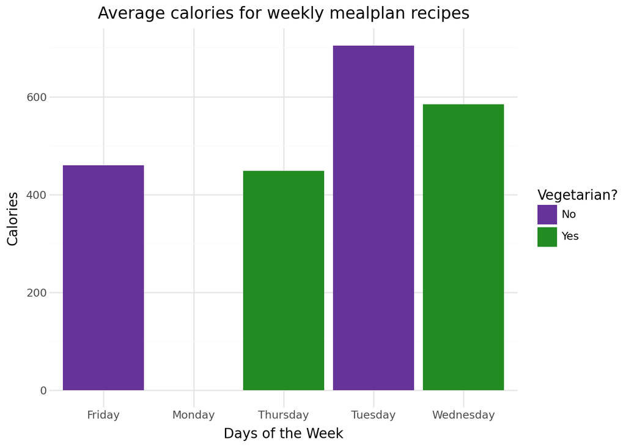

```python
# configure data for visualization
## finding mean of nutrition values per week day to find daily patterns, not individual recipe results
df_graph = df[["Day of the Week", "Name of Recipe", 'nutrition.calories', 'nutrition.carbohydrates', 'nutrition.fat', 'nutrition.fiber', 'nutrition.protein', 'nutrition.sugar']].groupby(["Day of the Week", "Name of Recipe"]).mean().reset_index()
vegetarian(df_graph)
df_graph

# set up custom colors for columns
custom_colors = {
    'Yes': 'forestgreen',
    'No': 'rebeccapurple'
    }

# column chart
(ggplot(df_graph,
aes(
    x = "Day of the Week",
    y = "nutrition.calories",
    fill = "Vegetarian?"
))
# columns
+ geom_col()
+ scale_fill_manual(values = custom_colors)
# axes and legends
+ labs(title= "Average calories for weekly mealplan recipes", x= "Days of the Week", y = "Calories", fill = "Vegetarian?")
# background
+ theme_minimal()
)
```

:::

This second graph compares the average calories, carbs, fat, fiber, protein, and sugar of each day’s recipes per Mealplan 202. The vegetarian days are denoted with the stars (“*“) after the day’s name along the x axis.

::: {#cell-Visualization of Mealplan 202 – detailed chart .cell execution_count=14}

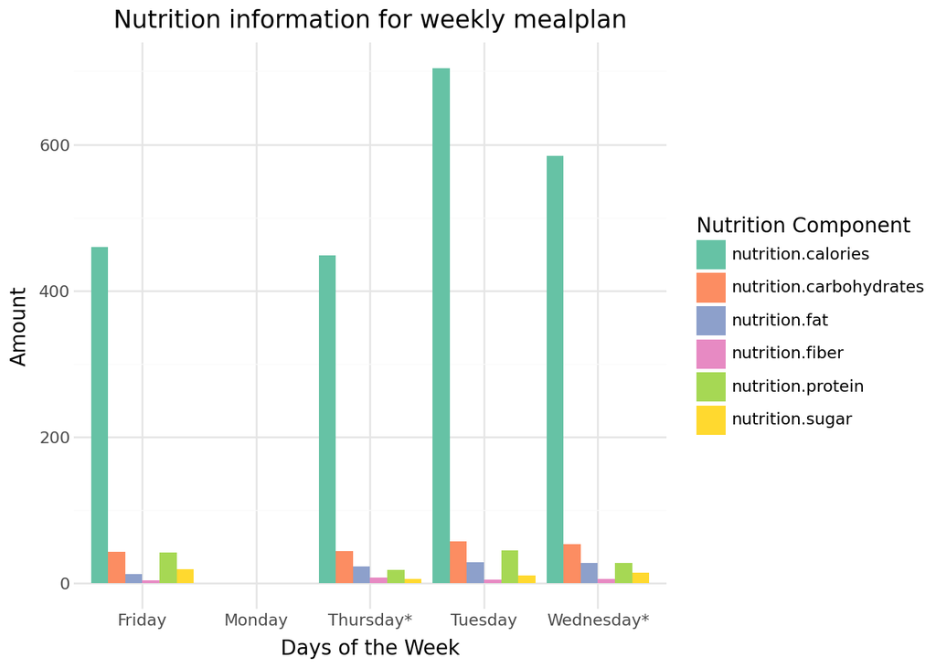

```python
# configure data for visualization
## finding mean of nutrition values per week day to find daily patterns, not individual recipe results
df_graph_fancy = df[["Day of the Week", "Name of Recipe", 'nutrition.calories', 'nutrition.carbohydrates', 'nutrition.fat', 'nutrition.fiber', 'nutrition.protein', 'nutrition.sugar']].groupby(["Day of the Week", "Name of Recipe"]).mean().reset_index()

## wide to long conversion to map to bar chart
df_graph_fancy = pd.melt(df_graph_fancy, id_vars=["Day of the Week", "Name of Recipe"], value_vars=['nutrition.calories', 'nutrition.carbohydrates','nutrition.fat', 'nutrition.fiber', 'nutrition.protein', 'nutrition.sugar'], var_name = "nutrition", value_name = "value")

# adding vegetarian info
df_graph_fancy = vegetarian(df_graph_fancy)
## making mark for vegetarian days
df_graph_fancy["Day of the Week"] = df_graph_fancy.apply(lambda x: x["Day of the Week"] + "*" if x["Vegetarian?"] == "Yes" else x["Day of the Week"], axis=1)
df_graph_fancy

# bar chart
(ggplot(df_graph_fancy,
aes(
    x = "Day of the Week",
    y = "value",
    fill = "nutrition"
))
# bars
+ geom_bar(stat = "identity", position = "dodge")
+ scale_fill_brewer(type = 'qual', palette='Set2')
# axes and legends
+ labs(title= "Nutrition information for weekly mealplan", x= "Days of the Week", y = "Amount", fill = "Nutrition Component")
# background
+ theme_minimal()
)
```

:::